# ECON6027_8b

Dr. Liu

# GEOSPATIAL ANALYSIS

Load the required packages.

```r
library(gstat); library(sf); library(tmap); library(automap)
```

## Dataset

Load and prep the “fulmar” sightings for the year 1999 dataset.

```r
data(fulmar); fulmar99 = fulmar[fulmar$year==1999, ]
(fulmar99 = st_as_sf(fulmar99, coords=c("x","y"), crs=32631))
```

```
## Simple feature collection with 729 features and 4 fields
## Geometry type: POINT
## Dimension:     XY
## Bounding box:  xmin: 476209.6 ymin: 5695049 xmax: 735071.7 ymax: 6143369
## Projected CRS: WGS 84 / UTM zone 31N
## First 10 features:
##     year depth     coast   fulmar                 geometry
## 605 1999    39  74.32973  0.00000 POINT (637495.6 5995275)
## 606 1999    39  66.93047  0.00000 POINT (599026.3 5970039)
## 607 1999    40  87.58816  6.83660 POINT (577184.1 5972975)
## 608 1999    33  66.16789  0.00000   POINT (518083 5797273)
## 609 1999    26  51.32900  0.00000 POINT (588319.2 5934117)
## 610 1999    21  33.62153  0.00000 POINT (507633.3 5733771)
## 611 1999    44  85.68657 28.42134 POINT (598002.6 5990036)
## 612 1999    36 140.23980  0.00000 POINT (515451.6 5989526)
## 613 1999    31  63.64503  0.00000 POINT (476209.6 5744903)
## 614 1999    25  41.07539  0.00000 POINT (591826.3 5922514)
```

## Kriging

### Empirical Semi-variance

Estimate the average squared differences between observations for distance bands: semi-variance

```r
evgm = variogram(fulmar~1, data=fulmar99) # automatic bandwidth selection
# evgm = variogram(fulmar~1, data=fulmar99, boundaries=seq(0,260000,l=53))
```

Use “fulmar~1” for ordinary or simple kriging (more on this later)

Next we determine the appropriate semi-variogram: trial and error method.

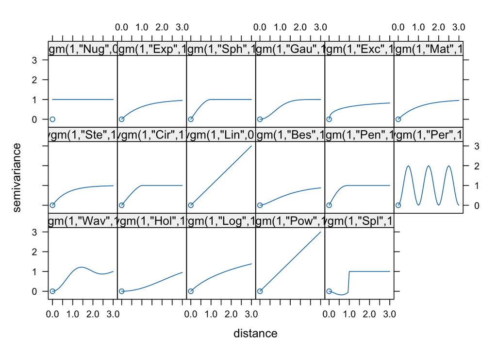

```r
show.vgms()
```

```r
vgm()
```

```
##    short                                      long
## 1    Nug                              Nug (nugget)
## 2    Exp                         Exp (exponential)
## 3    Sph                           Sph (spherical)
## 4    Gau                            Gau (gaussian)
## 5    Exc        Exclass (Exponential class/stable)
## 6    Mat                              Mat (Matern)
## 7    Ste Mat (Matern, M. Stein's parameterization)
## 8    Cir                            Cir (circular)
## 9    Lin                              Lin (linear)
## 10   Bes                              Bes (bessel)
## 11   Pen                      Pen (pentaspherical)
## 12   Per                            Per (periodic)
## 13   Wav                                Wav (wave)
## 14   Hol                                Hol (hole)
## 15   Log                         Log (logarithmic)
## 16   Pow                               Pow (power)
## 17   Spl                              Spl (spline)
## 18   Leg                            Leg (Legendre)
## 19   Err                   Err (Measurement error)
## 20   Int                           Int (Intercept)
```

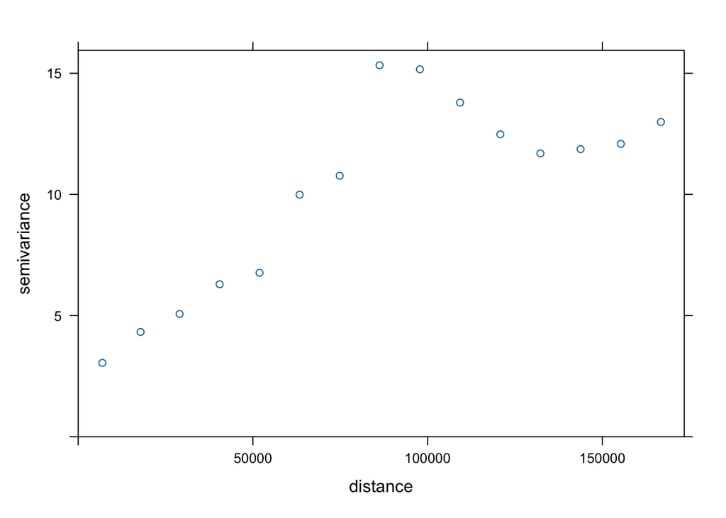

```r
plot(evgm) # initial plot
```

### Fit the empirical semi-variogram to a parametric fit

In the vgm() function, “psill”, “range” and “nugget” are initial guesses. You can use the plot(evgm) to identify the initial guesses.

1. Exponential fit without the nugget effect

```r
(fvgm = fit.variogram(evgm, vgm(psill=12, model="Exp", range=100000)))
```

```
##   model    psill   range
## 1   Exp 13.59704 46264.4
```

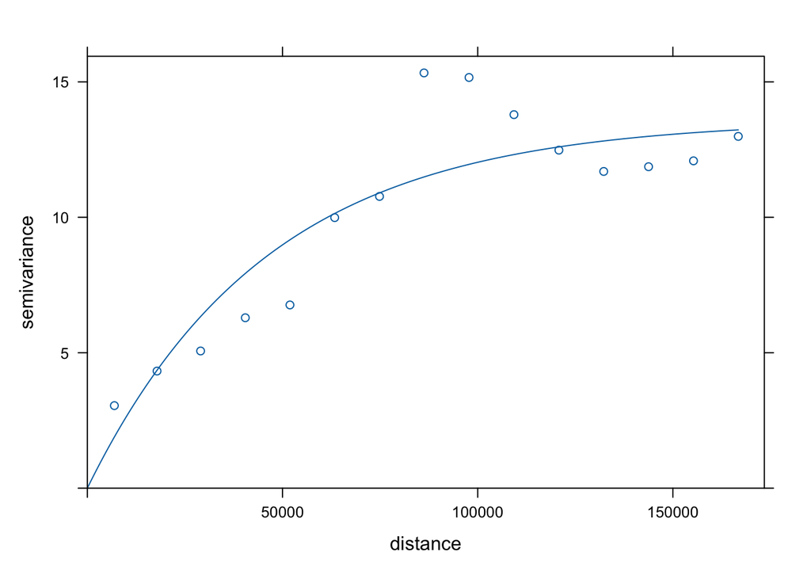

```r
plot(evgm, model=fvgm)
```

2. Exponential fit with nugget effect

```r
(fvgm = fit.variogram(evgm, vgm(psill=10, model="Exp", range=100000, nugget=2)))
```

```
##   model    psill    range
## 1   Nug  1.90407      0.0
## 2   Exp 18.15168 120992.1
```

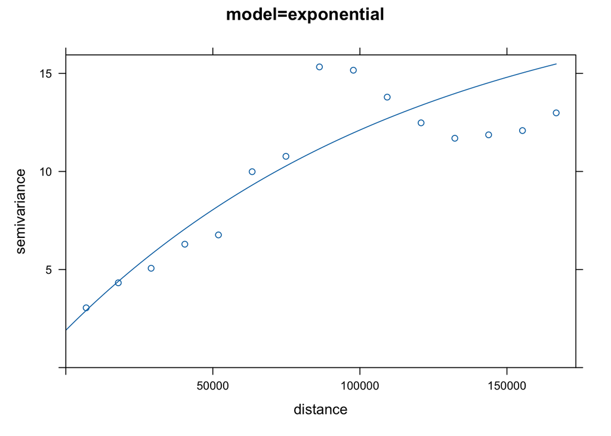

```r
plot(evgm, model=fvgm, main="model=exponential")
```

3. Activity A

```r
(fvgm = fit.variogram(evgm, vgm(psill=10, model="Gau", range=100000, nugget=2)))
```

```
##   model     psill    range
## 1   Nug  3.012413     0.00
## 2   Gau 11.010980 64349.73
```

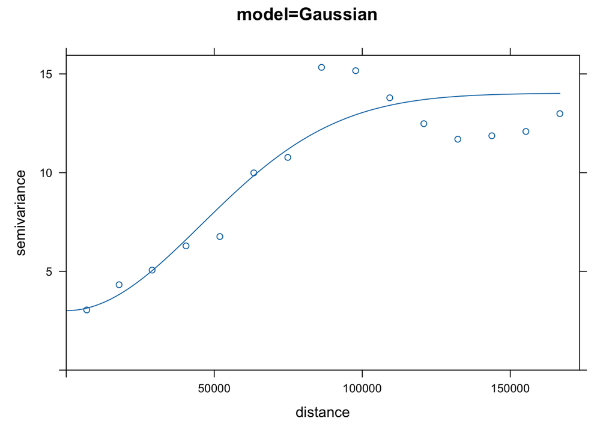

```r
plot(evgm, model=fvgm, main="model=Gaussian")
```

Alternative model fits: cir, pen, sph, bessel

4. Automatically fitting a variogram using the “automap” package

```r
fulmar99.sp = as(fulmar99, "Spatial") # automap currently accepts only projected sp objects.
(autovgm = autofitVariogram(fulmar~1, fulmar99.sp))
```

```
## $exp_var
##       np       dist     gamma dir.hor dir.ver   id
## 1    393   1784.391  2.901021       0       0 var1
## 2   1099   5870.347  1.786798       0       0 var1
## 3   1269   8731.925  4.297250       0       0 var1
## 4   2514  13875.243  3.645847       0       0 var1
## 5   2976  19231.834  3.515168       0       0 var1
## 6   3950  24431.539  5.504788       0       0 var1
## 7  16264  36637.791  6.044911       0       0 var1
## 8  20485  54703.306  7.875939       0       0 var1
## 9  37198  77231.559 12.431239       0       0 var1
## 10 36291 103969.539 14.249815       0       0 var1
## 11 32997 131163.796 11.983459       0       0 var1
## 12 37915 162590.448 12.434498       0       0 var1
##
## $var_model
##   model     psill    range
## 1   Nug  2.798431     0.00
## 2   Gau 10.745451 59275.79
##
## $sserr
## [1] 0.000100295
##
## attr(,"class")
## [1] "autofitVariogram" "list"
```

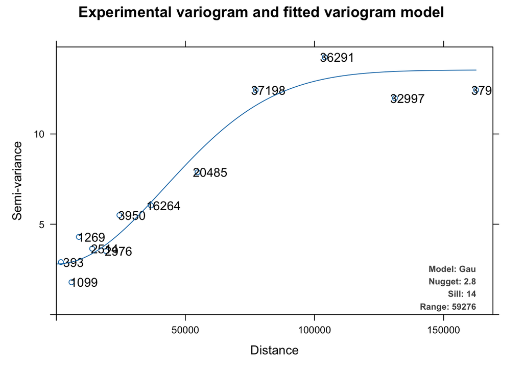

```r
plot(autovgm)
```

```r
class(autovgm)
```

```
## [1] "autofitVariogram" "list"
```

We will use the Gaussian model.

### Generate the set of unsampled points

The following unsampled points will be the locations we estimate the “fulmar” sighting values for.

```r
data(ncp.grid) # a set of unsampled points to reconstruct the surface
head(ncp.grid) # in practice you need to generate this using a random sample function
```

```
##        x       y depth coast area
## 1 511500 6129000    30   248    1
## 2 516500 6129000    30   247    1
## 3 521500 6129000    30   244    1
## 4 526500 6129000    30   242    1
## 5 531500 6129000    30   239    1
## 6 536500 6129000    30   237    1
```

```r
(ncp.gridsf = st_as_sf(ncp.grid, coords=c("x","y"), crs=32631))
```

```
## Simple feature collection with 2297 features and 3 fields
## Geometry type: POINT
## Dimension:     XY
## Bounding box:  xmin: 466500 ymin: 5699000 xmax: 736500 ymax: 6129000
## Projected CRS: WGS 84 / UTM zone 31N
## First 10 features:
##    depth coast area               geometry
## 1     30   248    1 POINT (511500 6129000)
## 2     30   247    1 POINT (516500 6129000)
## 3     30   244    1 POINT (521500 6129000)
## 4     30   242    1 POINT (526500 6129000)
## 5     30   239    1 POINT (531500 6129000)
## 6     30   237    1 POINT (536500 6129000)
## 7     30   234    1 POINT (541500 6129000)
## 8     30   232    1 POINT (546500 6129000)
## 9     30   230    1 POINT (551500 6129000)
## 10    31   228    1 POINT (556500 6129000)
```

### 1. Ordinary kriging estimate in R

f(x) = const

```r
(krig.est = krige(fulmar~1, fulmar99, newdata=ncp.gridsf, model=fvgm))
```

```
## [using ordinary kriging]
```

```
## Simple feature collection with 2297 features and 2 fields
## Geometry type: POINT
## Dimension:     XY
## Bounding box:  xmin: 466500 ymin: 5699000 xmax: 736500 ymax: 6129000
## Projected CRS: WGS 84 / UTM zone 31N
## First 10 features:
##    var1.pred var1.var               geometry
## 1  0.3883082 4.081830 POINT (511500 6129000)
## 2  0.6240462 3.755816 POINT (516500 6129000)
## 3  0.8926406 3.537472 POINT (521500 6129000)
## 4  1.1846822 3.407039 POINT (526500 6129000)
## 5  1.4892633 3.342729 POINT (531500 6129000)
## 6  1.7946843 3.324667 POINT (536500 6129000)
## 7  2.0892559 3.338115 POINT (541500 6129000)
## 8  2.3621259 3.375421 POINT (546500 6129000)
## 9  2.6040514 3.436477 POINT (551500 6129000)
## 10 2.8080414 3.527758 POINT (556500 6129000)
```

- Variable 1: prediction
- Variable 2: variance
- If no variogram is specified to the argument “model”, the function defaults to IDW interpolation with idp=2.

```r
summary(krig.est)
```

```
##    var1.pred           var1.var              geometry
##  Min.   :-0.78049   Min.   :3.079   POINT        :2297
##  1st Qu.: 0.09929   1st Qu.:3.129   epsg:32631   :   0
##  Median : 1.02496   Median :3.209   +proj=utm ...:   0
##  Mean   : 1.96869   Mean   :3.306
##  3rd Qu.: 2.92520   3rd Qu.:3.368
##  Max.   :12.83315   Max.   :6.280
```

Notice the negative frequencies, which must be “eliminated” in the plot.

OK Plot:

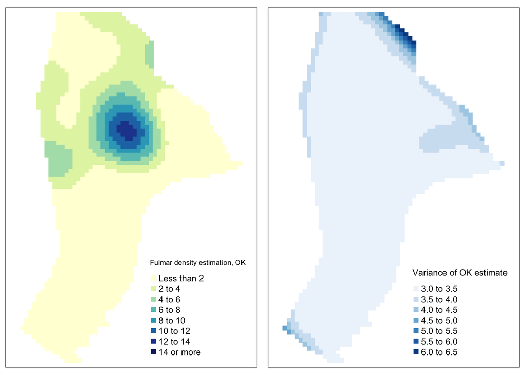

```r
OK_pred_map = tm_shape(krig.est) +
  tm_dots(col="var1.pred", palette="YlGnBu", shape=15, size = 0.2,
          breaks=c(-Inf,2,4,6,8,10,12,14,Inf), title="Fulmar density estimation, OK")
OK_var_map = tm_shape(krig.est) +
  tm_dots(col="var1.var", palette="Blues", shape=15, size = 0.2,
          title="Variance of OK estimate")
tmap_arrange(OK_pred_map, OK_var_map)
```

Variances are good to get a sense of the reliability of the estimates. Interpolations are at its most reliable in the light shaded areas with many observations close to the points compared to the dark shaded areas.

### 2. Simple kriging estimate in R

If you specify a value to the “beta” argument in the krige function, then the output is the simple kriging estimate. We will use the OLS estimate as the “beta” value (which is the same as the average fulmar sightings - 1.116475).

```r
lm(fulmar~1, fulmar99)
```

```
##
## Call:
## lm(formula = fulmar ~ 1, data = fulmar99)
##
## Coefficients:
## (Intercept)
##       1.116
```

```r
mean(fulmar99$fulmar)
```

```
## [1] 1.116475
```

Hence, the beta is specified as the mean of the observations.

```r
skrig.est = krige(fulmar~1, fulmar99, newdata=ncp.gridsf, beta=mean(fulmar99$fulmar), model=fvgm)
```

```
## [using simple kriging]
```

```r
summary(skrig.est) # negative estimates present!
```

```
##    var1.pred          var1.var              geometry
##  Min.   :-0.7810   Min.   :3.079   POINT        :2297
##  1st Qu.: 0.1013   1st Qu.:3.129   epsg:32631   :   0
##  Median : 1.0308   Median :3.209   +proj=utm ...:   0
##  Mean   : 1.9642   Mean   :3.305
##  3rd Qu.: 2.8959   3rd Qu.:3.368
##  Max.   :12.8301   Max.   :6.191
```

SK Plot:

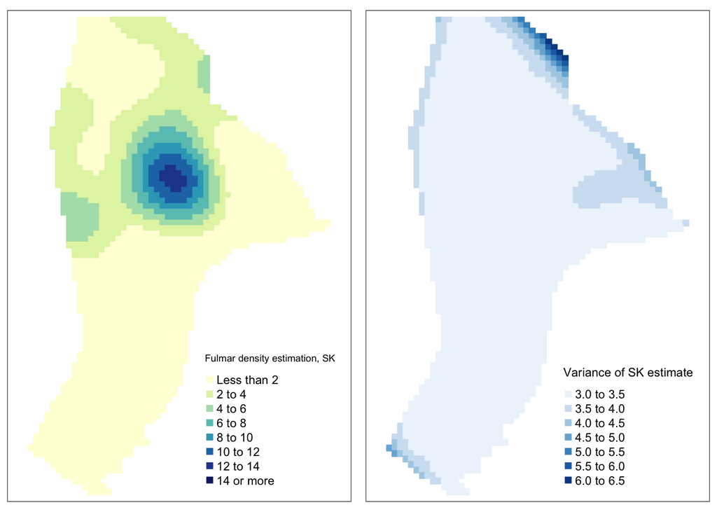

```r
SK_pred_map = tm_shape(skrig.est) +
  tm_dots(col="var1.pred", palette="YlGnBu", shape=15, size = 0.2,
          breaks=c(-Inf,2,4,6,8,10,12,14,Inf), title="Fulmar density estimation, SK")
SK_var_map = tm_shape(skrig.est) +
  tm_dots(col="var1.var", palette="Blues", shape=15, size = 0.2,
          title="Variance of SK estimate")
tmap_arrange(SK_pred_map, SK_var_map)
```

#### OK vs. SK

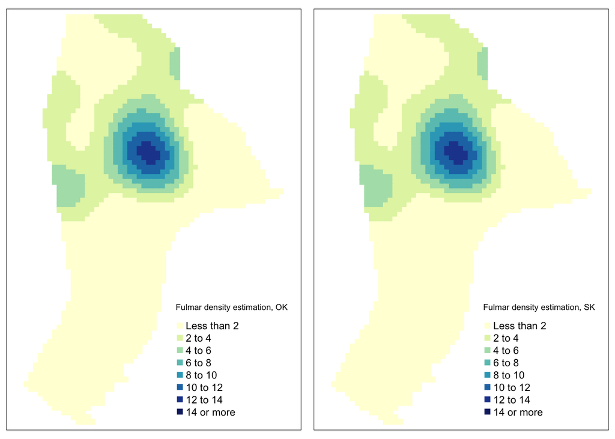

```r
tmap_arrange(OK_pred_map, SK_pred_map)
```

Notice there is not much difference between OK and SK, why?

This reiterates the fact that all kriging techniques honour data characteristics, preserve the mean (trend) and preserve the spatial autocorrelation structure and typically OK is a safe bet in many situations.

### 3. Universal kriging estimate in R

If we specify a regression equation in the krige function, then the output is the universal kriging estimate. You may run some possible regressions and select the one that fits the data the best.

```r
AIC(lm(fulmar~depth+coast, fulmar99)) # model 1
```

```
## [1] 3703.985
```

```r
AIC(lm(fulmar~depth, fulmar99)) # model 2
```

```
## [1] 3707.032
```

```r
AIC(lm(fulmar~coast, fulmar99)) # model 3
```

```
## [1] 3779.767
```

```r
AIC(lm(fulmar~1, fulmar99)) # model 0
```

```
## [1] 3842.252
```

Model 1 has the smallest AIC and hence is selected.

```r
(ukrig.est = krige(fulmar~depth+coast, fulmar99, newdata=ncp.gridsf, model=fvgm))
```

```
## [using universal kriging]
```

```
## Simple feature collection with 2297 features and 2 fields
## Geometry type: POINT
## Dimension:     XY
## Bounding box:  xmin: 466500 ymin: 5699000 xmax: 736500 ymax: 6129000
## Projected CRS: WGS 84 / UTM zone 31N
## First 10 features:
##    var1.pred var1.var               geometry
## 1  0.7067429 4.128579 POINT (511500 6129000)
## 2  0.8551985 3.777483 POINT (516500 6129000)
## 3  1.0273564 3.542798 POINT (521500 6129000)
## 4  1.2408276 3.407767 POINT (526500 6129000)
## 5  1.4685986 3.343493 POINT (531500 6129000)
## 6  1.7169229 3.326616 POINT (536500 6129000)
## 7  1.9574854 3.342430 POINT (541500 6129000)
## 8  2.1968602 3.381906 POINT (546500 6129000)
## 9  2.4172453 3.447846 POINT (551500 6129000)
## 10 2.6503907 3.542670 POINT (556500 6129000)
```

```r
summary(ukrig.est)
```

```
##    var1.pred          var1.var              geometry
##  Min.   :-0.8979   Min.   :3.085   POINT        :2297
##  1st Qu.: 0.1789   1st Qu.:3.134   epsg:32631   :   0
##  Median : 1.0121   Median :3.211   +proj=utm ...:   0
##  Mean   : 1.9966   Mean   :3.313
##  3rd Qu.: 2.9687   3rd Qu.:3.375
##  Max.   :12.8485   Max.   :6.408
```

UK Plot:

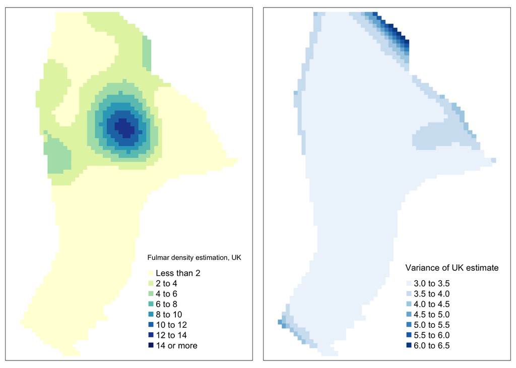

```r
UK_pred_map = tm_shape(ukrig.est) +
  tm_dots(col="var1.pred", palette="YlGnBu", shape=15, size = 0.2,
          breaks=c(-Inf,2,4,6,8,10,12,14,Inf), title="Fulmar density estimation, UK")
UK_var_map = tm_shape(ukrig.est) +
  tm_dots(col="var1.var", palette="Blues", shape=15, size = 0.2,
          title="Variance of UK estimate")
tmap_arrange(UK_pred_map, UK_var_map)
```

#### OK vs. SK vs. UK

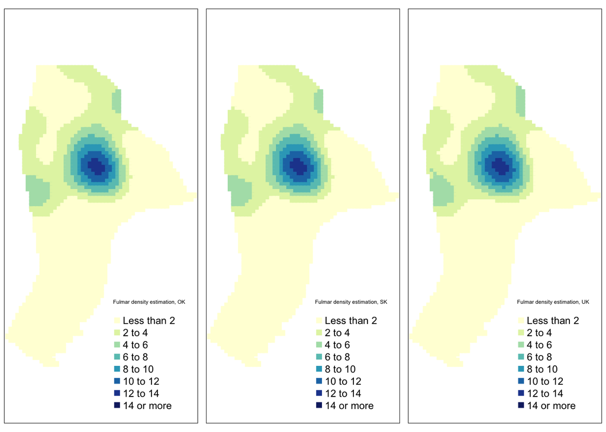

```r
tmap_arrange(OK_pred_map, SK_pred_map, UK_pred_map)
```

As before, notice there is not much difference among the three estimates. So in reality one needs not employ all three methods. Ordinary Kriging is the usual default option.